# Practice Code: Day 4

Author

Constantin Manuel Bosancianu

Published

August 1, 2019

# 1 Introduction

We start as yesterday, by loading a few needed packages, and by defining a few custom functions we use below.

```python
import pandas as pd
pd.set_option('display.precision', 2)
import numpy as np
import pyreadr as prr
import os
import random
from plotnine import *
import statsmodels.formula.api as sm1
import statsmodels.api as sm2
import statsmodels.stats.api as sms
import scipy as sp
import matplotlib.pyplot as plt
```

We also define here a few helpful functions we will rely on in this code file.

```python
def fun_two_SD(x):
    return (x - np.mean(x, axis = 0)) / (2 * np.std(x))

def fun_cent_noSD(x):
     return x - np.mean(x)
```

# 2 Data input and preparation

We’ll use the same data set as in the previous days. We’re keeping only the variables we’re interested in - compared to the previus days, I will add an additional level-2 predictor.

```python
result = prr.read_r("../02-data/01-ISSP.rds")
df_issp = result[None]

df_issp = df_issp[['cnt', 'year', 'country', 'poleff', 'female',
                   'age10', 'educ', 'urban', 'incquart', 'ti_cpi',
                   'gini10']].dropna()

df_dumm = pd.get_dummies(df_issp['incquart'], prefix = 'inc')

frames = [df_issp, df_dumm]
df_issp = pd.concat(frames, axis = 1)
```

## 2.1 Centering

Let’s go again through the centering procedures we went through yesterday, and generate the last 3 models we looked at.

```python
df_grouped = df_issp.groupby('cnt')[['age10', 'female', 'educ',
          'urban', 'inc_1', 'inc_2',
          'inc_3', 'inc_4']].transform(lambda x: fun_two_SD(x))
df_grouped = df_grouped.rename({'age10': 'age10CWC',
                                'female': 'femCWC',
                                'educ': 'educCWC',
                                'urban': 'urbanCWC',
                                'inc_1': 'inc1CWC',
                                'inc_2': 'inc2CWC',
                                'inc_3': 'inc3CWC',
                                'inc_4': 'inc4CWC'},
                               axis = 1)

df_issp = pd.concat([df_issp, df_grouped], axis = 1)
```

```python
df_agg = df_issp.groupby('cnt')[['ti_cpi', 'gini10']].mean().reset_index()
df_agg[['cpiCGM', 'giniCGM']] = df_agg[['ti_cpi', 'gini10']].apply(fun_two_SD)
df_agg = df_agg.drop(['ti_cpi', 'gini10'], axis = 1)
```

```python
df_issp = df_issp.merge(df_agg, on = 'cnt', how = 'left')
```

## 2.2 Initial specifications

We estimate 4 specifications, in increasing level of complexity, starting with the null model.[^1]

<sup>1</sup> In order to be able to extract common measures of model fit in addition to the *log-likelihood*, we have to estimate the specifications with standard ML (not REML).

```python
mlm_0 = sm1.mixedlm("poleff ~ 1",
                    data = df_issp,
                    groups = df_issp["cnt"]).fit(reml = False)

mlm_1 = sm1.mixedlm("poleff ~ age10CWC + femCWC + educCWC + urbanCWC +\
                         inc2CWC + inc3CWC + inc4CWC + cpiCGM",
                    data = df_issp,
                    groups = df_issp["cnt"]).fit(reml = False)

mlm_2 = sm1.mixedlm("poleff ~ age10CWC + femCWC + educCWC + urbanCWC +\
                         inc2CWC + inc3CWC + inc4CWC + cpiCGM",
                    re_formula = "~educCWC",
                    data = df_issp,
                    groups = df_issp["cnt"]).fit(reml = False)

mlm_3 = sm1.mixedlm("poleff ~ age10CWC + femCWC + educCWC + urbanCWC +\
                         inc2CWC + inc3CWC + inc4CWC + cpiCGM + educCWC * cpiCGM",
                    re_formula = "~educCWC",
                    data = df_issp,
                    groups = df_issp["cnt"]).fit(reml = False)

print(mlm_0.summary(), mlm_1.summary(), mlm_2.summary(), mlm_3.summary())
```

```
          Mixed Linear Model Regression Results
=========================================================
Model:            MixedLM Dependent Variable: poleff
No. Observations: 37628   Method:             ML
No. Groups:       35      Scale:              0.5215
Min. group size:  517     Log-Likelihood:     -41232.5459
Max. group size:  2202    Converged:          Yes
Mean group size:  1075.1
----------------------------------------------------------
            Coef.  Std.Err.    z     P>|z|  [0.025  0.975]
----------------------------------------------------------
Intercept   2.963     0.050  58.728  0.000   2.864   3.062
Group Var   0.089     0.030
=========================================================
           Mixed Linear Model Regression Results
=========================================================
Model:            MixedLM Dependent Variable: poleff
No. Observations: 37628   Method:             ML
No. Groups:       35      Scale:              0.4740
Min. group size:  517     Log-Likelihood:     -39431.3887
Max. group size:  2202    Converged:          Yes
Mean group size:  1075.1
---------------------------------------------------------
              Coef.  Std.Err.    z    P>|z| [0.025 0.975]
---------------------------------------------------------
Intercept      2.963    0.044  67.501 0.000  2.877  3.049
age10CWC       0.123    0.007  16.462 0.000  0.108  0.137
femCWC        -0.120    0.007 -16.826 0.000 -0.134 -0.106
educCWC        0.319    0.008  40.667 0.000  0.304  0.335
urbanCWC       0.043    0.007   6.010 0.000  0.029  0.057
inc2CWC        0.060    0.009   6.812 0.000  0.043  0.077
inc3CWC        0.116    0.009  12.995 0.000  0.099  0.134
inc4CWC        0.224    0.009  24.102 0.000  0.206  0.242
cpiCGM         0.294    0.088   3.353 0.001  0.122  0.466
Group Var      0.067    0.023
=========================================================
              Mixed Linear Model Regression Results
===============================================================
Model:              MixedLM   Dependent Variable:   poleff
No. Observations:   37628     Method:               ML
```

[output cut: 30 more lines]

```
---------------------------------------------------------------
Intercept            2.963    0.044  67.431 0.000  2.877  3.049
age10CWC             0.122    0.007  16.245 0.000  0.107  0.136
femCWC              -0.121    0.007 -17.003 0.000 -0.135 -0.107
educCWC              0.322    0.019  17.063 0.000  0.285  0.359
urbanCWC             0.044    0.007   6.166 0.000  0.030  0.059
inc2CWC              0.057    0.009   6.510 0.000  0.040  0.074
inc3CWC              0.114    0.009  12.716 0.000  0.096  0.131
inc4CWC              0.219    0.009  23.537 0.000  0.201  0.237
cpiCGM               0.294    0.088   3.350 0.001  0.122  0.467
educCWC:cpiCGM       0.107    0.037   2.868 0.004  0.034  0.180
Group Var            0.067    0.024
Group x educCWC Cov -0.006    0.007
educCWC Var          0.010    0.004
===============================================================
```

# 3 Model fit

<sup>2</sup> Which you can also extract with `model_object.llf`.

```python
mlm_1.llf
mlm_2.llf
mlm_3.llf
```

```
-39328.01408999332
```

You also have functions for AIC and BIC (there’s not much sense to have a function for deviance, since it’s computed as $-2 * logLik$).

```python
mlm_1.aic
mlm_2.aic
mlm_3.aic
```

```
78684.02817998664
```

```python
mlm_1.bic
mlm_2.bic
mlm_3.bic
```

```
78803.52523224991
```

Unfortunately, there isn’t a automated test that can compare the model fit, as the `anova_lm()` function only handles linear models in **Python**. However, you can easily do such a test manually, if you remember that:

1. The deviance is computed as $-2 \times logLik$
2. The difference of 2 deviances for nested models has a $\chi^2$ distribution
3. The degrees of freedom for this test are the difference in estimated model parameters between the two models

With this information, you can check if your difference is *larger* than the critical threshold for the $\chi^2$ distribution for a specific number of degrees of freedom.[^3]

<sup>3</sup> See an example table here: https://people.richland.edu/james/lecture/m170/tbl-chi.html.

```python
dev_2 = -2 * mlm_2.llf
dev_3 = -2 * mlm_3.llf

dev_2 - dev_3
```

```
7.296889245742932
```

Since we only estimated one additional parameter between `mlm_2` and `mlm_3` (one interaction term), the number of degrees of freedom is 1. At this level, the difference we obtain definitely clears the critical threshold of 3.841, which means `mlm_3` fits the data significantly better than `mlm_2`.

As an additional specification, let’s also try a model that includes Gini as predictor for the intercept at L1.

```python
mlm_4 = sm1.mixedlm("poleff ~ age10CWC + femCWC + educCWC + urbanCWC +\
                         inc2CWC + inc3CWC + inc4CWC + cpiCGM + giniCGM +\
                          educCWC * cpiCGM",
                    re_formula = "~educCWC",
                    data = df_issp,
                    groups = df_issp["cnt"]).fit(reml = False)
print(mlm_4.summary())
```

```
             Mixed Linear Model Regression Results
===============================================================
Model:              MixedLM   Dependent Variable:   poleff
No. Observations:   37628     Method:               ML
No. Groups:         35        Scale:                0.4706
Min. group size:    517       Log-Likelihood:       -39327.8585
Max. group size:    2202      Converged:            Yes
Mean group size:    1075.1
---------------------------------------------------------------
                    Coef.  Std.Err.    z    P>|z| [0.025 0.975]
---------------------------------------------------------------
Intercept            2.963    0.044  66.855 0.000  2.876  3.050
age10CWC             0.122    0.007  16.247 0.000  0.107  0.136
femCWC              -0.121    0.007 -17.002 0.000 -0.135 -0.107
educCWC              0.322    0.019  17.041 0.000  0.285  0.360
urbanCWC             0.044    0.007   6.163 0.000  0.030  0.059
inc2CWC              0.057    0.009   6.507 0.000  0.040  0.074
inc3CWC              0.114    0.009  12.713 0.000  0.096  0.131
inc4CWC              0.219    0.009  23.535 0.000  0.201  0.237
cpiCGM               0.264    0.104   2.531 0.011  0.059  0.468
giniCGM             -0.064    0.113  -0.566 0.571 -0.285  0.157
educCWC:cpiCGM       0.107    0.037   2.863 0.004  0.034  0.180
Group Var            0.068    0.025
Group x educCWC Cov -0.008    0.009
educCWC Var          0.010    0.004
===============================================================
```

Is there maybe a differential effect of Gini on education groups, though?

```python
mlm_5 = sm1.mixedlm("poleff ~ age10CWC + femCWC + educCWC + urbanCWC +\
                         inc2CWC + inc3CWC + inc4CWC + cpiCGM + giniCGM +\
                          educCWC * cpiCGM + educCWC * giniCGM",
                    re_formula = "~educCWC",
                    data = df_issp,
                    groups = df_issp["cnt"]).fit(reml = False)
print(mlm_5.summary())
```

```
             Mixed Linear Model Regression Results
===============================================================
Model:              MixedLM   Dependent Variable:   poleff
No. Observations:   37628     Method:               ML
No. Groups:         35        Scale:                0.4706
Min. group size:    517       Log-Likelihood:       -39322.9714
Max. group size:    2202      Converged:            Yes
Mean group size:    1075.1
---------------------------------------------------------------
                    Coef.  Std.Err.    z    P>|z| [0.025 0.975]
---------------------------------------------------------------
Intercept            2.963    0.044  67.578 0.000  2.877  3.049
age10CWC             0.122    0.007  16.250 0.000  0.107  0.136
femCWC              -0.121    0.007 -17.019 0.000 -0.135 -0.107
educCWC              0.323    0.017  19.491 0.000  0.291  0.356
urbanCWC             0.044    0.007   6.163 0.000  0.030  0.059
inc2CWC              0.057    0.009   6.485 0.000  0.040  0.074
inc3CWC              0.114    0.009  12.712 0.000  0.096  0.131
inc4CWC              0.219    0.009  23.562 0.000  0.201  0.237
cpiCGM               0.303    0.100   3.027 0.002  0.107  0.500
giniCGM              0.019    0.100   0.187 0.852 -0.178  0.215
educCWC:cpiCGM       0.046    0.037   1.225 0.221 -0.028  0.119
educCWC:giniCGM     -0.122    0.036  -3.346 0.001 -0.194 -0.051
Group Var            0.067    0.023
Group x educCWC Cov -0.006    0.006
educCWC Var          0.007    0.003
===============================================================
```

Which one fits the data better?

```python
dev_4 = -2 * mlm_4.llf
dev_5 = -2 * mlm_5.llf

dev_3 - dev_4
dev_4 - dev_5
```

```
9.774223242304288
```

# 4 Diagnostic checks

Let’s take Model 5, which seemed to be the most promising of all the specifications tested so far, at least if we judge based on the indices of model fit discussed earlier today and the manual LRT I conducted above.

Start from examining Level-1 residuals.

```python
df_issp['resid'] = mlm_5.resid
```

## 4.1 Linearity

Look at a plot of residuals vs. the outcome…

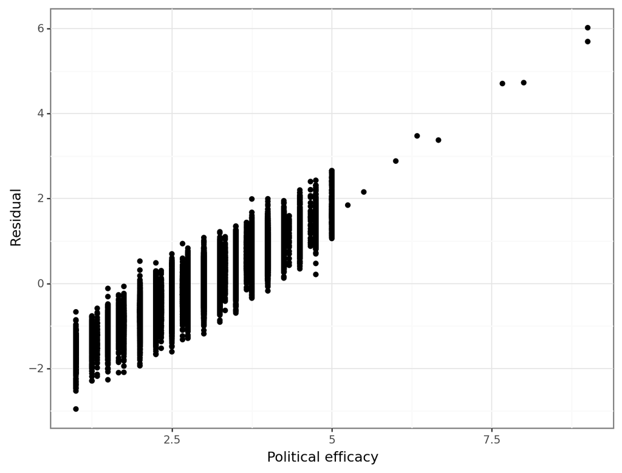

```python
(
     ggplot(df_issp) +
     geom_point(aes(x = "poleff",
                    y = "resid")) +
     labs(x = "Political efficacy",
          y = "Residual") +
     theme_bw() +
     theme(figure_size = (8, 6))
)
```

It’s normal that it’s tilted; getting rid of the tilt requires you to plot residuals against fitted values. Try it and see what comes out.

… as well as residuals against the predictors at L1.

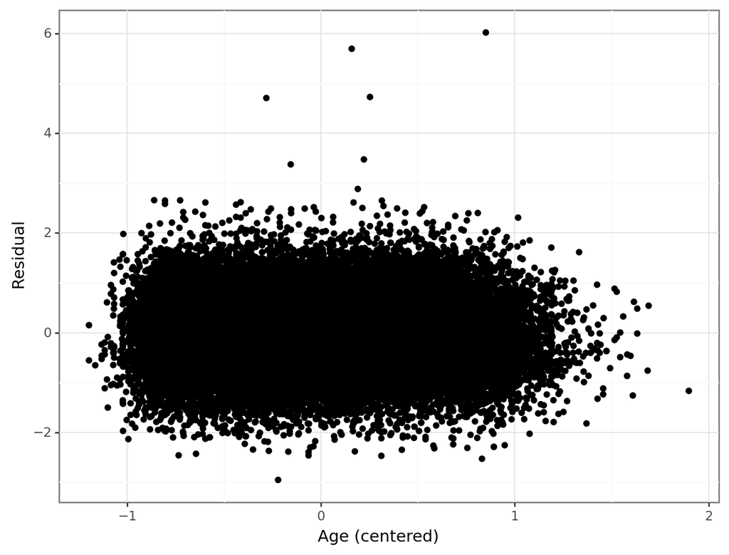

```python
(
     ggplot(df_issp) +
     geom_point(aes(x = "age10CWC",
                    y = "resid")) +
     labs(x = "Age (centered)",
          y = "Residual") +
     theme_bw() +
     theme(figure_size = (8, 6))
)
```

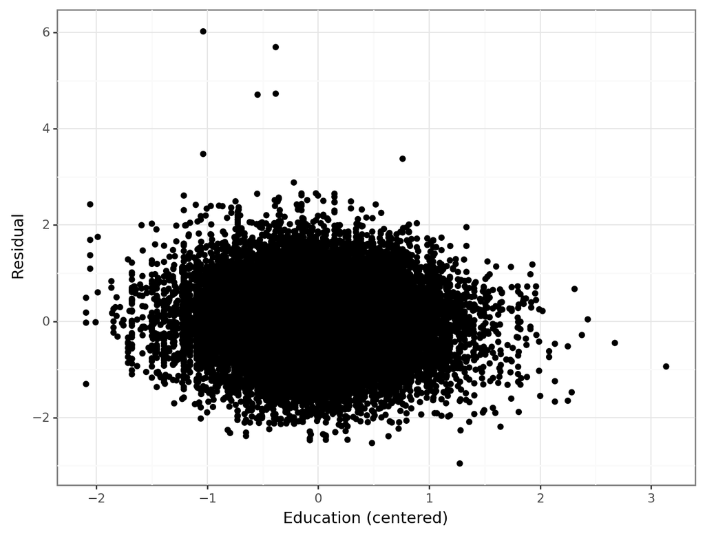

```python
(
     ggplot(df_issp) +
     geom_point(aes(x = "educCWC",
                    y = "resid")) +
     labs(x = "Education (centered)",
          y = "Residual") +
     theme_bw() +
     theme(figure_size = (8, 6))
)
```

With dichotomous predictors there is not much chance to diagnose a non-linear trend, so we won’t need to generate these plots.

## 4.2 Homogeneity of variance across groups

This is the Bartlett-Kendall test we discussed.

```python
data = [df_issp[df_issp['cnt'] == "AU"]['resid'],
        df_issp[df_issp['cnt'] == "AT"]['resid'],
        df_issp[df_issp['cnt'] == "CL"]['resid'],
        df_issp[df_issp['cnt'] == "TW"]['resid'],
        df_issp[df_issp['cnt'] == "HR"]['resid'],
        df_issp[df_issp['cnt'] == "CZ"]['resid'],
        df_issp[df_issp['cnt'] == "DK"]['resid'],
        df_issp[df_issp['cnt'] == "FI"]['resid'],
        df_issp[df_issp['cnt'] == "FR"]['resid'],
        df_issp[df_issp['cnt'] == "GE"]['resid'],
        df_issp[df_issp['cnt'] == "IS"]['resid'],
        df_issp[df_issp['cnt'] == "IN"]['resid'],
        df_issp[df_issp['cnt'] == "JP"]['resid'],
        df_issp[df_issp['cnt'] == "KR"]['resid'],
        df_issp[df_issp['cnt'] == "LT"]['resid'],
        df_issp[df_issp['cnt'] == "NL"]['resid'],
        df_issp[df_issp['cnt'] == "NO"]['resid'],
        df_issp[df_issp['cnt'] == "PH"]['resid'],
        df_issp[df_issp['cnt'] == "PL"]['resid'],
        df_issp[df_issp['cnt'] == "RU"]['resid'],
        df_issp[df_issp['cnt'] == "SK"]['resid'],
        df_issp[df_issp['cnt'] == "SI"]['resid'],
        df_issp[df_issp['cnt'] == "ZA"]['resid'],
        df_issp[df_issp['cnt'] == "ES"]['resid'],
        df_issp[df_issp['cnt'] == "SE"]['resid'],
        df_issp[df_issp['cnt'] == "CH"]['resid'],
        df_issp[df_issp['cnt'] == "TR"]['resid'],
        df_issp[df_issp['cnt'] == "US"]['resid'],
        df_issp[df_issp['cnt'] == "VE"]['resid'],
        df_issp[df_issp['cnt'] == "BE"]['resid'],
        df_issp[df_issp['cnt'] == "DE"]['resid'],
        df_issp[df_issp['cnt'] == "IL"]['resid'],
        df_issp[df_issp['cnt'] == "GB"]['resid'],
        df_issp[df_issp['cnt'] == "EE"]['resid'],
        df_issp[df_issp['cnt'] == "NZ"]['resid']]

sp.stats.bartlett(data[0], data[1], data[2], data[3], data[4],
                  data[5], data[6], data[7], data[8], data[9],
                  data[10], data[11], data[12], data[13], data[14],
                  data[15], data[16], data[17], data[18], data[19],
                  data[20], data[21], data[22], data[23], data[24],
                  data[25], data[26], data[27], data[28], data[29],
                  data[30], data[31], data[32], data[33], data[34])
```

```
BartlettResult(statistic=463.3613363661305, pvalue=8.529274550856327e-77)
```

Unfortunately, we soundly reject $H_0$, which means that we do **NOT** have homogeneity of variances of residuals across countries.

```python
df_grouped = df_issp.groupby('cnt')['resid'].var().reset_index()
df_grouped.to_html()
```

|  | cnt | resid |
| --- | --- | --- |
| 0 | AT | 0.51 |
| 1 | AU | 0.46 |
| 2 | BE | 0.50 |
| 3 | CH | 0.38 |
| 4 | CL | 0.40 |
| 5 | CZ | 0.52 |
| 6 | DE | 0.52 |
| 7 | DK | 0.62 |
| 8 | EE | 0.38 |
| 9 | ES | 0.50 |
| 10 | FI | 0.52 |
| 11 | FR | 0.34 |
| 12 | GB | 0.43 |
| 13 | GE | 0.46 |
| 14 | HR | 0.42 |
| 15 | IL | 0.49 |
| 16 | IN | 0.42 |
| 17 | IS | 0.46 |
| 18 | JP | 0.48 |
| 19 | KR | 0.37 |
| 20 | LT | 0.44 |
| 21 | NL | 0.41 |
| 22 | NO | 0.42 |
| 23 | NZ | 0.65 |
| 24 | PH | 0.34 |
| 25 | PL | 0.46 |
| 26 | RU | 0.46 |
| 27 | SE | 0.45 |
| 28 | SI | 0.33 |
| 29 | SK | 0.50 |
| 30 | TR | 0.45 |
| 31 | TW | 0.51 |
| 32 | US | 0.47 |
| 33 | VE | 0.69 |
| 34 | ZA | 0.52 |

If this was an analysis intended for publishing there would be little reason to advance further, but for didactic purposes we can proceed.

## 4.3 Normally-distributed errors

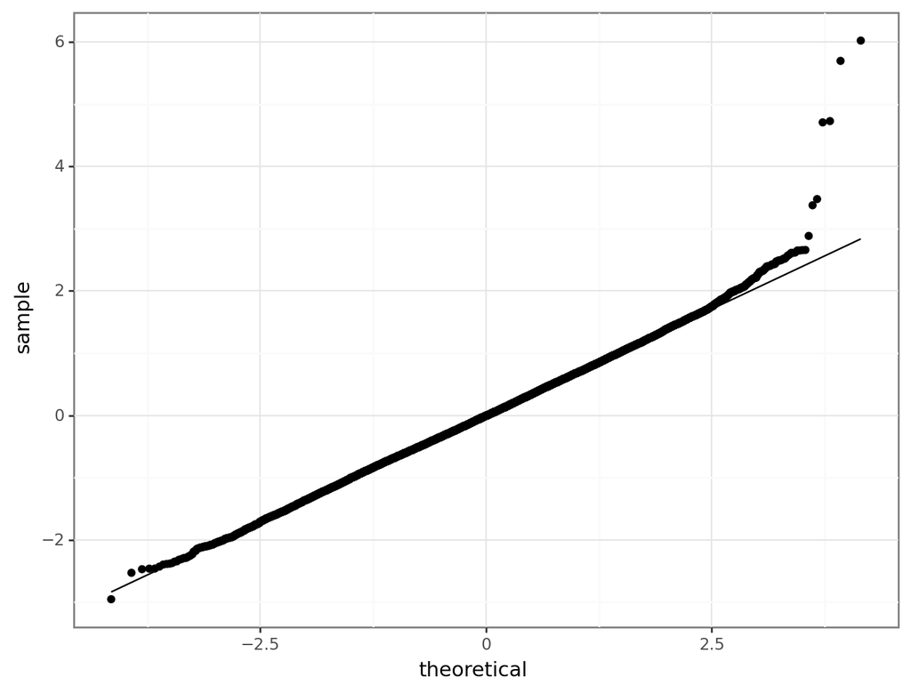

```python
(
     ggplot(df_issp,
            aes(sample = "resid")) +
     stat_qq() +
     stat_qq_line() +
     theme_bw() +
     theme(figure_size = (8, 6))
)
```

## 4.4 Level 2 residuals

Unfortunately, automatically generating this quantity is not yet implemented as part of the `statsmodels` package.

# 5 Package versions

Package versions used in this script.

1. `ipykernel` 6.21.2
2. `ipython` 8.11.0
3. `jupyter_client` 8.0.3
4. `jupyter_core` 5.2.0
5. `matplotlib` 3.7.0
6. `matplotlib-inline` 0.1.6
7. `numpy` 1.24.2
8. `pandas` 1.5.3
9. `plotnine` 0.10.1
10. `pyreadr` 0.4.7
11. `scipy` 1.10.1
12. `stargazer` 0.0.5
13. `statsmodels` 0.13.5